# Calculus3 Density, Cumulative, Hazard

ryamada

2017年1月22日

確率密度関数を積分すると累積密度関数。

Integrate probability density function, then it is cumulative density function.

累積密度関数を微分すると確率密度関数。 Differentiate cumulative density function, then it is density function.

確率分布の本体は同じで、その見方が異なっているだけ。 Both density and cumulative density functions represent the same function and they are two ways to show it.

いろいろな見方を扱い、それらの微積分関係を確認する。

Some other ways to represent probability function follow.

# 1 確率密度関数 Probability density function $f(x)$

確率変数$X$が値$x$をとる確率密度を$P(X=x)$と書く。

Let $P(X=x)$ denote the probability density of X being x

確率密度関数 Probability density function.
$$f(x) = P(X=x)\\
f(x) \ge 0\\
\int_{x\in D} f(x) = 1$$

指数分布を例に取ると In case of exponential distribution,

$$f(x) = \lambda e^{-\lambda x}
D = [0;\infty)$$

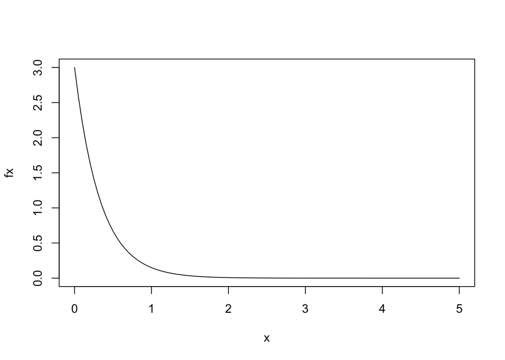

```r
lambda <- 3
x <- seq(from=0,to=5,length=100)
fx <- lambda * exp(-lambda *x)
plot(x,fx,type="l")
```

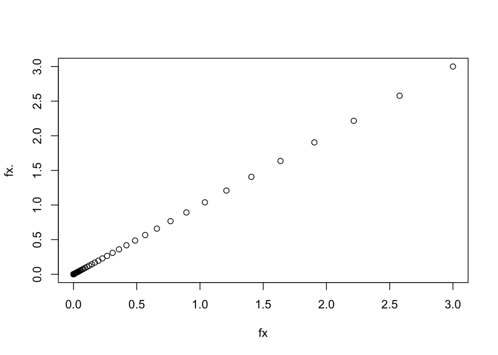

```r
fx. <- dexp(x,lambda)
plot(fx,fx.)
```

# 2 累積分布関数 Cumulative distribution function $F(x)$

$$F(x) = P(X \le x) = \int_{}^x f(x) dx\\
\frac{d}{dx} F(x) = f(x)$$

指数分布の場合 Exponential distribution:

$$F(x) = \int_{0}^x f(t) dt\\
= \int_0^x \lambda e^{-\lambda t}dt\\
= [\lambda \frac{1}{-\lambda} e^{-\lambda t}]^x_0 \\
= - e^{-\lambda x} + e^{0}\\
= 1-e^{-\lambda x}$$

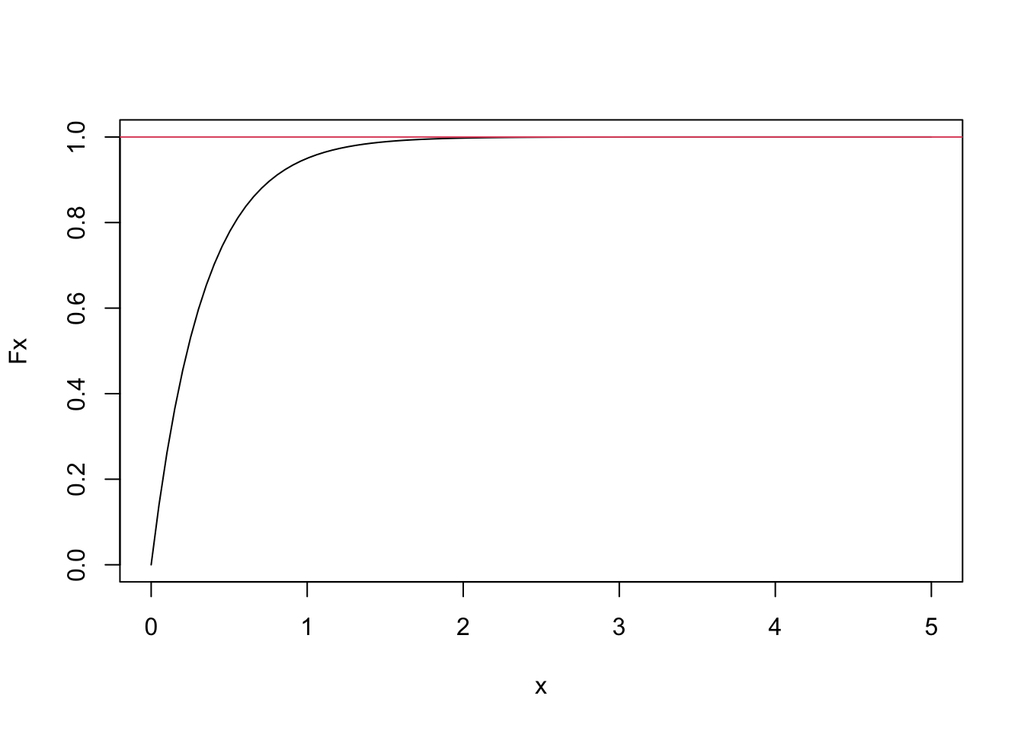

```r
Fx <- 1-exp(-lambda*x)
plot(x,Fx,type="l")
abline(h=1,col=2)
```

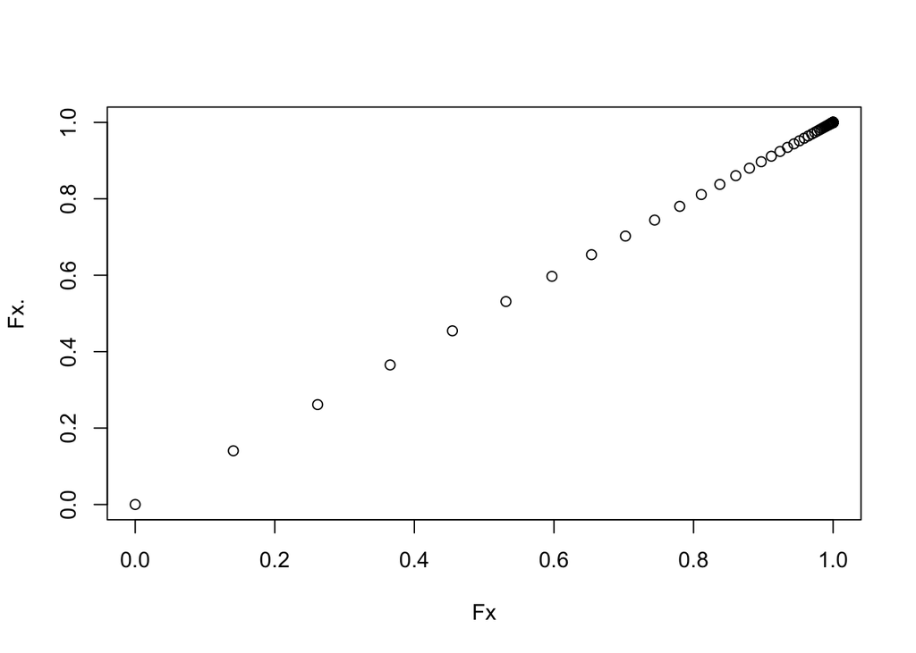

```r
Fx. <- pexp(x,lambda,lower.tail=TRUE)
plot(Fx,Fx.)
```

# 3 生存関数 Survival function $S(x)$

The order of x in $F(x)$ is inversed.

累積分布関数$F(x)$の昇降順を逆にした関数。

$P(X=x)$を時刻$X=x$での瞬間死亡率とすると、$S(x)$は時刻$X=x$での生存者の割合

When the $P(X=x)$ is probability of death at time $X=x$, then $S(x)$ stands for the fraction of survivers at time $X=x$.

$$S(x) = P(X>x)\\
S(x) = 1- F(x) = \int_x^{} f(x) dx\\
=1- (1-e^{-\lambda x}) \\
= e^{-\lambda x}$$

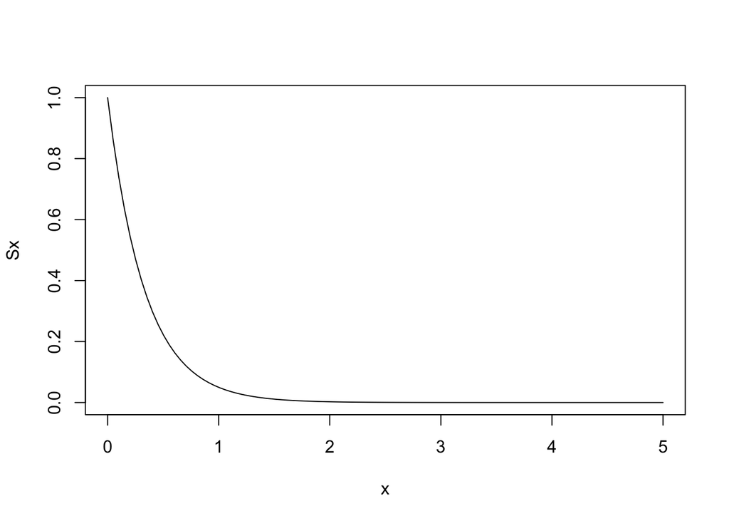

```r
Sx <- exp(-lambda * x)
plot(x,Sx,type="l")
```

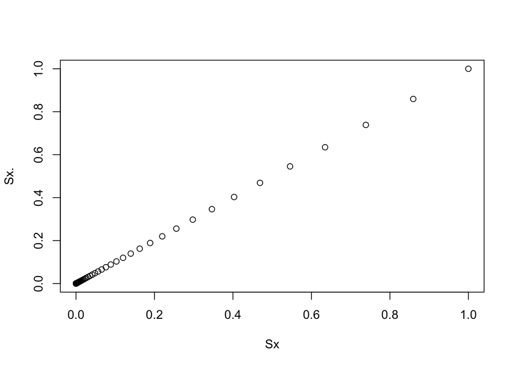

```r
Sx. <- pexp(x,lambda,lower.tail=FALSE)
plot(Sx,Sx.)
```

# 逆累積分布関数 Inverse of cumulative density function $G(t)$

$$P(X \le G(t)) = t\\
\int_{}^{G(t)} f(x) dx = t\\
F(G(t)) = t\\
G(t) = F^{-1}(t)$$

$$F(G(t)) = t\\
F(G(t)) = t = 1-e^{-\lambda G(t)}\\
e^{-\lambda G(t)} = 1-t\\
-\lambda G(t) = \log{1-t}\\
G(t) = -\frac{\log{(1-t)}}{\lambda}$$

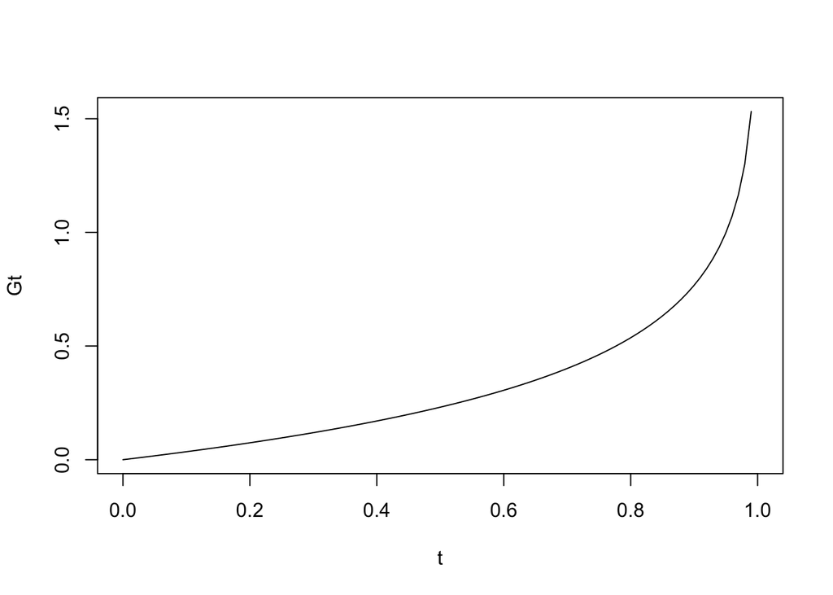

```r
t <- seq(from=0,to=1,length=100)
Gt <- -(log(1-t))/lambda
plot(t,Gt,type="l")
```

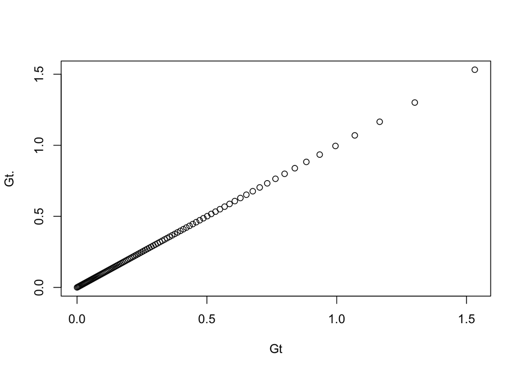

```r
Gt. <- qexp(t,lambda)
plot(Gt,Gt.)
```

# 4 逆生存関数 Inverse of survival function $Z(x)$

$$P(X>Z(t)) = t\\
\int_{Z(t)}^{} f(x) dx = t\\
S(Z(t)) = t\\
Z(t) = S^{-1}(t)$$

$$S(Z(t)) = t\\
S(Z(t)) = t = e^{-\lambda Z(t)}\\
\lambda Z(t) = - \log{t}\\
Z(t) = -\frac{\log{t}}{\lambda}$$

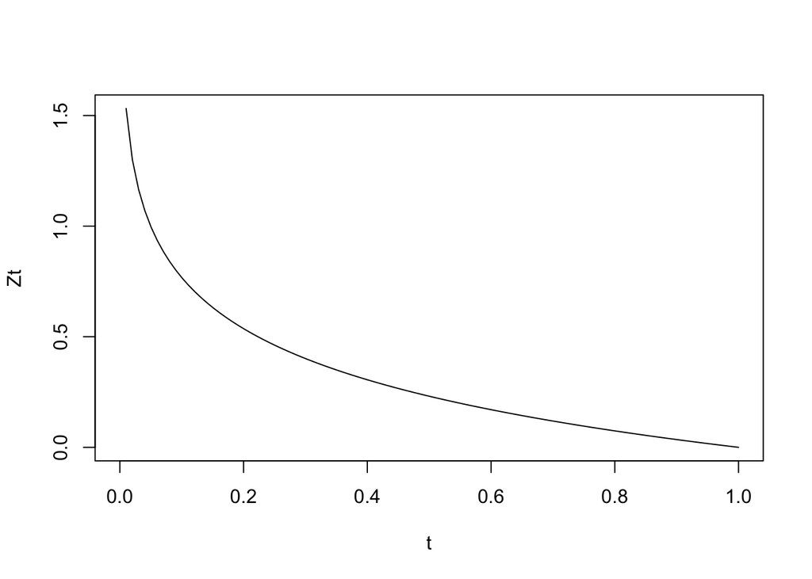

```r
Zt <- -log(t)/lambda
plot(t,Zt,type="l")
```

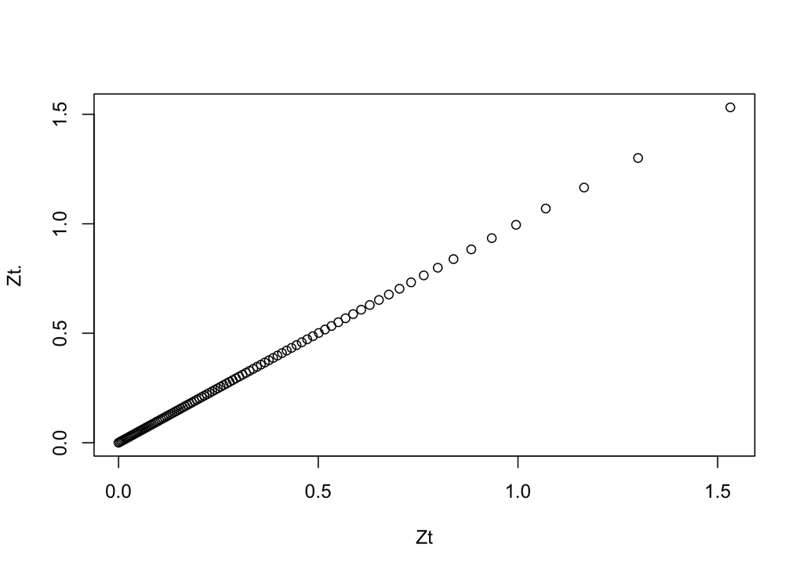

```r
Zt. <- qexp(t,lambda,lower.tail=FALSE)
plot(Zt,Zt.)
```

# 5 ハザード関数 Hazard function $h(x)$

$$h(x) = \frac{f(x)}{S(x)}\\
h(x) = \frac{f(x)}{\int_x^{} f(x) dx}$$
$$\frac{d}{dx} F(x) = f(x)\\
S(x) = 1- F(x)\\
\frac{d}{dx} S(x) = -\frac{d}{dx}F(x) = -f(x)$$

$$h(x) = -\frac{\frac{d}{dx}S(x)}{S(x)}\\
= - \frac{d}{dx} (\log{S(x)})$$

$$f(x) = \lambda e^{-\lambda x}\\
S(x) = e^{-\lambda x}\\
h(x) = \frac{f(x)}{S(x)} = \lambda\\
h(x) = -\frac{d}{dx} \log{S(x)}\\
= -\frac{d}{dx} \log{e^{-\lambda x}}\\
= -\frac{d}{dx} (-\lambda x)\\
= \lambda$$
生き残っている部分$S(x)$の死亡率(瞬間死亡率)

Probability to die for the survivers.

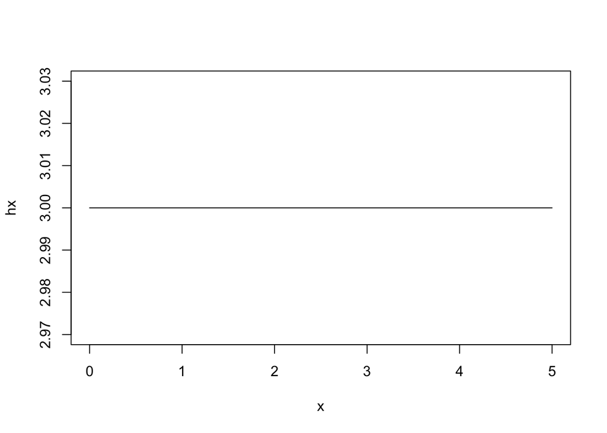

```r
hx <- fx/Sx
plot(x,hx,type="l")
```

指数分布とは、「どの時点においても、生き残っている部分での瞬間死亡率が一定」である分布

# 6 累積ハザード関数 Cumulative hazard function $H(x)$

$$\frac{d}{dx}H(x) = h(x) = -\frac{d}{dx} \log{S(x)}\\
H(x) = -\log{S(x)}$$

$$H(x) = -\log{S(x)} = -\log{e^{-\lambda x}}= \lambda x$$

# 7 Exercise 1

## 7.1 Exercise 1-1

生存時間のモデル、機械が故障するまでの時間のモデルのひとつが指数分布である。

Exponential distribution is one of stochastic models of survival time (time to death) or time to failure.

別のモデルとしてワイブル分布がある。

Weibull distribution is one of them.

ワイブル分布の確率密度分布は The probability density distribution of Weibull distribution is;

$$f(x) = k\lambda (\lambda x)^{k-1} e^{-(\lambda x)^k}$$
で与えられる。

このワイブル分布の生存関数、ハザード関数を求め、指数分布のそれと比較せよ

Calculate survival function and hazard function for Weibull distribution, then compare them with ones of exponential distribution.